# Reversible jump for variable selection

NIMBLE ENAR 2020 short course

NIMBLE Development Team

# Introduction to Bayesian variable selection

- You have many candidate explanatory variables.
- Bayesian approach is to have a probability that a variable is included in the model.
- Really this is a probability that the coefficient is $\ne 0$.
- BUGS/JAGS implementation is with indicator variables.

```
  linear_predictor[i] <- beta0 + ind * beta1 * x[i]
```

- This has problems: when `ind` is 0, `beta1` follows its prior, until it hits a reasonable value for `beta1` that allows `ind` equal to 1 to be accepted.
- “Solution”: informative priors

# Solution!: Reversible Jump MCMC

- RJMCMC is a method for sampling across different models.
- Specifically it is about sampling between different numbers of dimensions.
- In full generality, RJ requires one to figure out a way to propose reasonable parameter values when moving between models. Hard!
- RJ for variable selection is relatively simple.
  - We don’t change the actual NIMBLE model object, but we turn on and off which dimensions are sampled.
  - Implementation, like all samplers, is written using `nimbleFunction`s.

Recall that we had two covariates in the AFT model - blood urea nitrogen and hemoglobin. Let’s see if hemoglobin is needed in the model using Bayesian variable selection.

# RJMCMC for variable selection in nimble

- Update an MCMC configuration to use RJMCMC.

```r
if(!exists('model'))  ## need AFT setup code when generating html from Rmd
  source("9_survival_analysis.R")
model_sel <- model$newModel(replicate = TRUE)  # or we could just `nimbleModel` again with the original model code
```

```
## checking model sizes and dimensions... This model is not fully initialized. This is not an error. To see which variables are not initialized, use model$initializeInfo(). For more information on model initialization, see help(modelInitialization).
```

```r
cmodel_sel <- compileNimble(model_sel)
```

```
## compiling... this may take a minute. Use 'showCompilerOutput = TRUE' to see C++ compilation details.
## compilation finished.
```

```r
conf_sel <- configureMCMC(model_sel)
configureRJ(conf_sel,
            targetNodes = 'delta[2]',
            priorProb = 0.5,
            control = list(mean = 0, scale = 2))
mcmc_sel <- buildMCMC(conf_sel)
cmcmc_sel <- compileNimble(mcmc_sel, project = model_sel)
```

```
## compiling... this may take a minute. Use 'showCompilerOutput = TRUE' to see C++ compilation details.
## compilation finished.
```

# Running the MCMC

```r
resultsAFT <- runMCMC(cmcmc_sel, niter = 21000, nburnin = 1000)
```

```
## running chain 1...
```

```
## |-------------|-------------|-------------|-------------|
## |-------------------------------------------------------|
```

Let’s look at the MCMC behavior of the coefficient of interest.

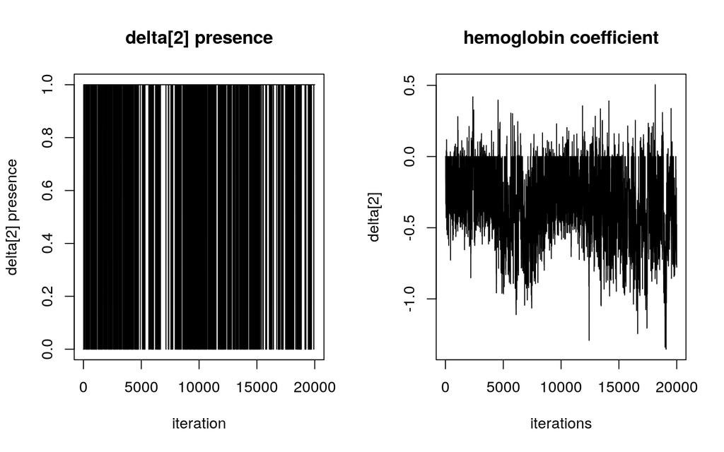

```r
par(mfrow = c(1,2))
ts.plot(resultsAFT[ , 'delta[2]'] != 0, xlab = 'iteration', ylab = 'delta[2] presence',
                    main = 'delta[2] presence')
ts.plot(resultsAFT[ , 'delta[2]'], xlab = 'iterations', ylab = 'delta[2]',
               main = 'hemoglobin coefficient')
```

```r
## posterior probability of inclusion
mean(resultsAFT[ , 'delta[2]'] != 0)
```

```
## [1] 0.7565
```

# Summary of RJMCMC

- Mixing will generally be better than simply using an indicator function without RJMCMC.
- One can use RJ for variable selection in NIMBLE either with or without indicator functions.
- Use of indicator functions allows for hierarchical structure for selection of multiple variables.
- Adaptation for coefficient samplers only occurs when the coefficient is “in the model”.
- Run time should be much faster *if* posterior probability of inclusion is not large.
- Tuning parameter of RJ proposal scale (sd) must be chosen.